# CFPS data analysis

Lin Wenzheng

2024-12-17

# Research Question

- The effect of parenting motivation on pro-environmental behaviors

# Parenting motivation

- 抚育动机(parenting motivation)，或抚育动机系统(parental care motivational system)，是指一系列旨在照顾脆弱的年幼儿的情感和认知机制(Buckels et al.,2015; Griskevicius & Kenrick, 2013; Li et al., 2019)
- CFPS 2018+2022: qka202

```
## [1] "期望孩子数（个）"
```

# Parenting motivation on pro-environmental behaviors

- 抚育是人类繁衍和生存的重要行为 (Geary 2000; Hill and Hurtado 1996)
- 抚育动机是促发这一行为的内在心理机制 (Buckels et al. 2015; Griskevicius and Kenrick 2013; Kenrick et al. 2010)
- 因此，高抚育动机使个体更关注后代和人类长久福祉，更能规避短视而破坏人类长期利益的行为
- 环保行为试图保障环境的可持续性，维护人类的长期生存环境 (Tian & Liu, 2022)
- 家庭人均水电与能源支出；控制家庭年收入与支出

```r
lapply(df2[, c("fp402","fp403","fp404","fml_count.x")], function(x) attr(x, "label"))
```

```
## $fp402
## [1] "每月水费（元）"
##
## $fp403
## [1] "每月电费（元）"
##
## $fp404
## [1] "每月燃料费（元）"
##
## $fml_count.x
## [1] "加载变量：2018年家庭成员人数"
```

```r
# lapply(df2[, c("finc","finc_est","finc1")], function(x) attr(x, "label"))
# lapply(df2[, c("fexp","fexp_est","fexp1")], function(x) attr(x, "label"))
```

# 2022: Cross-sectional model

```r
my.lme1 <- lmer(env_expavg2~ scale(qka202)+scale(age)+scale(gender)+scale(finc_corrected)+scale(fexp_corrected) + (1|provcd22.x), data=df5_22, REML=F)
summary(my.lme1)
```

```
## Linear mixed model fit by maximum likelihood . t-tests use Satterthwaite's
##   method [lmerModLmerTest]
## Formula:
## env_expavg2 ~ scale(qka202) + scale(age) + scale(gender) + scale(finc_corrected) +
##     scale(fexp_corrected) + (1 | provcd22.x)
##    Data: df5_22
##
##      AIC      BIC   logLik deviance df.resid
##  95598.5  95654.2 -47791.3  95582.5     7732
##
## Scaled residuals:
##     Min      1Q  Median      3Q     Max
## -1.4978 -0.4806 -0.2269  0.1769 17.9655
##
## Random effects:
##  Groups     Name        Variance Std.Dev.
##  provcd22.x (Intercept)   404.1   20.1
##  Residual               13416.1  115.8
## Number of obs: 7740, groups:  provcd22.x, 31
##
## Fixed effects:
##                        Estimate Std. Error        df t value Pr(>|t|)
## (Intercept)            109.5251     4.2096   29.2420  26.018  < 2e-16 ***
## scale(qka202)           -5.5460     1.4774 7574.9766  -3.754 0.000175 ***
## scale(age)               5.9090     1.5085 7646.5771   3.917 9.04e-05 ***
## scale(gender)            2.4896     1.2491 7728.2715   1.993 0.046289 *
## scale(finc_corrected)    2.6750     2.0350 7739.8954   1.315 0.188709
## scale(fexp_corrected)    0.9958     1.9748 7729.9909   0.504 0.614094
## ---
## Signif. codes:  0 '***' 0.001 '**' 0.01 '*' 0.05 '.' 0.1 ' ' 1
##
## Correlation of Fixed Effects:
##             (Intr) s(202) scal(g) scl(gn) scl(fn_)
## scal(qk202)  0.003
## scale(age)   0.052 -0.352
## scale(gndr) -0.011 -0.004 -0.028
## scl(fnc_cr) -0.013  0.013  0.066   0.004
## scl(fxp_cr)  0.006 -0.011 -0.016  -0.012  -0.803
```

# Indirect effect

```r
lapply(df1_person20[, qme_items], function(x) attr(x, "label"))
```

```
## $qme201
## [1] "为了年老时有人帮助"
##
## $qme202
## [1] "为了延续家族香火"
##
## $qme203
## [1] "为从经济上帮助家庭"
##
## $qme204
## [1] "为看孩子长大的喜悦"
##
## $qme205
## [1] "为子女在身边的快乐"
##
## $qme206
## [1] "为感受有宝宝的喜悦"
##
## $qme207
## [1] "为使家庭更重要"
##
## $qme208
## [1] "为增强责任心"
##
## $qme209
## [1] "为增加亲属联系"
```

- qme201~qme203：传统价值观
- qme204~qme206：情绪反馈
- qme207~qme209：社会责任

### 1-1-1 Mediation

```r
my.lme1 <- lmer(env_expavg2_20~ qka202+fermotiv1_20+fermotiv2_20 + fermotiv3_20+age+gender+finc_corrected+fexp_corrected + (1|provcd18.x), data=df8, REML=F)
lme_step4 <- summary(my.lme1)
lme_step4
```

```
## Linear mixed model fit by maximum likelihood . t-tests use Satterthwaite's
##   method [lmerModLmerTest]
## Formula:
## env_expavg2_20 ~ qka202 + fermotiv1_20 + fermotiv2_20 + fermotiv3_20 +
##     age + gender + finc_corrected + fexp_corrected + (1 | provcd18.x)
##    Data: df8
##
##      AIC      BIC   logLik deviance df.resid
## 107931.2 108009.7 -53954.6 107909.2     9234
##
## Scaled residuals:
##     Min      1Q  Median      3Q     Max
## -2.2472 -0.5155 -0.2384  0.2001 18.5502
##
## Random effects:
##  Groups     Name        Variance Std.Dev.
##  provcd18.x (Intercept)  302.4   17.39
##  Residual               6816.9   82.56
## Number of obs: 9245, groups:  provcd18.x, 30
##
## Fixed effects:
##                  Estimate Std. Error         df t value Pr(>|t|)
## (Intercept)     9.750e+01  9.571e+00  1.187e+03  10.187  < 2e-16 ***
## qka202         -2.812e+00  1.271e+00  9.202e+03  -2.212    0.027 *
## fermotiv1_20   -9.875e+00  2.161e+00  9.244e+03  -4.569 4.96e-06 ***
## fermotiv2_20   -3.818e+00  3.107e+00  9.233e+03  -1.229    0.219
## fermotiv3_20    1.880e+00  3.196e+00  9.228e+03   0.588    0.556
## age             4.404e-01  6.893e-02  9.205e+03   6.389 1.75e-10 ***
## gender          3.170e+00  2.957e+00  9.233e+03   1.072    0.284
## finc_corrected  7.178e-05  1.397e-05  9.242e+03   5.140 2.81e-07 ***
## fexp_corrected  2.706e-05  1.647e-05  9.225e+03   1.643    0.100
## ---
## Signif. codes:  0 '***' 0.001 '**' 0.01 '*' 0.05 '.' 0.1 ' ' 1
##
## Correlation of Fixed Effects:
##             (Intr) qka202 fr1_20 fr2_20 fr3_20 age    gender fnc_cr
## qka202      -0.126
## fermotv1_20 -0.115 -0.079
## fermotv2_20 -0.425 -0.002 -0.111
## fermotv3_20 -0.232 -0.005 -0.316 -0.547
## age         -0.134 -0.268 -0.226  0.086 -0.065
## gender      -0.134  0.020 -0.053  0.051 -0.045 -0.005
## finc_crrctd -0.117  0.032  0.086 -0.025  0.003  0.051  0.018
## fexp_crrctd -0.065 -0.004  0.041  0.000  0.005  0.026 -0.006 -0.563
## fit warnings:
## Some predictor variables are on very different scales: consider rescaling
```

```r
lme_step4$coefficients["qka202","Estimate"]
```

```
## [1] -2.811995
```

```r
my.lme2 <- lmer(fermotiv1_20~ qka202+age+gender+finc_corrected+fexp_corrected + (1|provcd18.x), data=df8, REML=F)
lme_step21 <- summary(my.lme2)
my.lme3 <- lmer(fermotiv2_20~ qka202+age+gender+finc_corrected+fexp_corrected + (1|provcd18.x), data=df8, REML=F)
lme_step22 <- summary(my.lme3)
my.lme4 <- lmer(fermotiv3_20~ qka202+age+gender+finc_corrected+fexp_corrected + (1|provcd18.x), data=df8, REML=F)
lme_step23 <- summary(my.lme4)
```

```r
# my.lme21 <- lmer(scale(fermotiv1_20)~ scale(qka202)+(1|provcd18.x), data=df8, REML=F)
# lme21 <- summary(my.lme5)
# my.lme22 <- lmer(scale(fermotiv2_20)~ scale(qka202)+(1|provcd18.x), data=df8, REML=F)
# lme22 <- summary(my.lme5)
# my.lme23 <- lmer(scale(fermotiv3_20)~ scale(qka202)+(1|provcd18.x), data=df8, REML=F)
# lme23 <- summary(my.lme5)
```

```r
RMediation::medci(lme_step21$coefficients["qka202","Estimate"],
                  lme_step4$coefficients["fermotiv1_20","Estimate"],
                  se.x=lme_step21$coefficients["qka202","Std. Error"],
                  se.y=lme_step4$coefficients["fermotiv1_20","Std. Error"],
                  type="MC")
```

```
## $`95% CI`
##       2.5%      97.5%
## -0.9097587 -0.3275211
##
## $Estimate
## [1] -0.6016792
##
## $SE
## [1] 0.1485225
##
## $`MC Error`
## [1] 1.485225e-06
```

```r
RMediation::medci(lme_step22$coefficients["qka202","Estimate"],
                  lme_step4$coefficients["fermotiv2_20","Estimate"],
                  se.x=lme_step22$coefficients["qka202","Std. Error"],
                  se.y=lme_step4$coefficients["fermotiv2_20","Std. Error"],
                  type="MC")
```

```
## $`95% CI`
##        2.5%       97.5%
## -0.21208494  0.04278788
##
## $Estimate
## [1] -0.07256599
##
## $SE
## [1] 0.06431397
##
## $`MC Error`
## [1] 6.431397e-07
```

```r
RMediation::medci(lme_step23$coefficients["qka202","Estimate"],
                  lme_step4$coefficients["fermotiv3_20","Estimate"],
                  se.x=lme_step23$coefficients["qka202","Std. Error"],
                  se.y=lme_step4$coefficients["fermotiv3_20","Std. Error"],
                  type="MC")
```

```
## $`95% CI`
##       2.5%      97.5%
## -0.1195267  0.2299803
##
## $Estimate
## [1] 0.04999154
##
## $SE
## [1] 0.08742497
##
## $`MC Error`
## [1] 8.742497e-07
```

- Parametric Bootstrapping using Monte Carlo method with 100000 resamples.

## Contextual effect

`r ggplot()+ # 绘制主图 geom_sf(data = china_eea,aes(fill = qka202_pm)) + scale_fill_continuous_sequential(name="期望孩子数/个",palette = "Greens 3")+ # 绘制国境线及十/九段线 # geom_sf(data = gjx)+ # geom_text(data = province,aes(x=dili_Jd,y=dili_Wd,label=省市), # position = "identity",size=3,check_overlap = TRUE) + labs(title="CFPS 各省份家庭生育意愿",subtitle="",caption = "")+ theme( plot.title = element_text(color="black", size=16, face="bold",vjust = 0.1,hjust = 0.5), plot.subtitle = element_text(size=10,vjust = 0.1,hjust = 0.5), legend.title=element_text(size=10,vjust = 0.1,hjust = 0.5), legend.position.inside = c(1,50), panel.grid=element_blank(), panel.background=element_blank(), axis.text=element_blank(), axis.ticks=element_blank(), axis.title=element_blank() )`

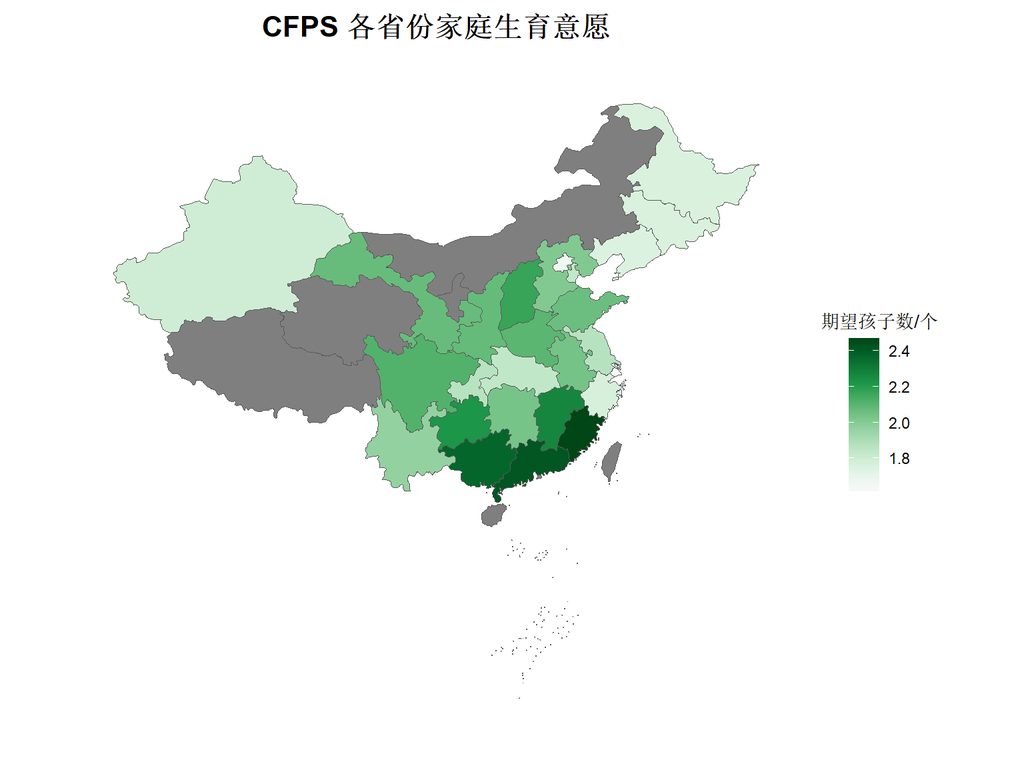

- Province mean included

`r my.lme1 <- lmer(env_expavg2_20~ I(qka202-qka202_pm)+fermotiv1_20+fermotiv2_20 + fermotiv3_20+age+gender+finc_corrected+fexp_corrected + qka202_pm + (1|provcd18.x), data=df8_pm, REML=F)`

`## Warning: Some predictor variables are on very different scales: consider ## rescaling ## Warning: Some predictor variables are on very different scales: consider ## rescaling`

`r lme_step4 <- summary(my.lme1)`

`r my.lme2 <- lmer(fermotiv1_20~ I(qka202-qka202_pm)+age+gender+finc_corrected+fexp_corrected + qka202_pm +(1|provcd18.x), data=df8_pm, REML=F) lme_step21 <- summary(my.lme2) my.lme3 <- lmer(fermotiv2_20~ I(qka202-qka202_pm)+age+gender+finc_corrected+fexp_corrected + qka202_pm + (1|provcd18.x), data=df8_pm, REML=F) lme_step22 <- summary(my.lme3) my.lme4 <- lmer(fermotiv3_20~ I(qka202-qka202_pm)+age+gender+finc_corrected+fexp_corrected +qka202_pm + (1|provcd18.x), data=df8_pm, REML=F) lme_step23 <- summary(my.lme4)`

`r RMediation::medci(lme_step21$coefficients["I(qka202 - qka202_pm)","Estimate"], lme_step4$coefficients["fermotiv1_20","Estimate"], se.x=lme_step21$coefficients["I(qka202 - qka202_pm)","Std. Error"], se.y=lme_step4$coefficients["fermotiv1_20","Std. Error"], type="MC")`

`` ## $`95% CI` ## 2.5% 97.5% ## -0.8769787 -0.3117082 ## ## $Estimate ## [1] -0.5772955 ## ## $SE ## [1] 0.1444584 ## ## $`MC Error` ## [1] 1.444584e-06 ``

# Three-wave model: 2018-2022

```r
# c3y_lme1 <- lmer(env_expavg2_22~ I(qka202-qka202_pm)+I(fermotiv1_20-fmv1_20_pm)+I(fermotiv2_20-fmv2_20_pm) + I(fermotiv3_20-fmv3_20_pm)+age+gender+finc_corrected+fexp_corrected + qka202_pm +fmv1_20_pm +fmv2_20_pm+fmv3_20_pm  + (1|provcd18.x), data=df6_pm, REML=F)
# cy3.op1 <- summary(c3y_lme1)
c3y_lme <- lmer(env_expavg2_22~ I(qka202-qka202_pm)+age+gender+finc_corrected+fexp_corrected + qka202_pm  + (1|provcd18.x), data=df6_pm, REML=F)
summary(c3y_lme)
```

```
## Linear mixed model fit by maximum likelihood . t-tests use Satterthwaite's
##   method [lmerModLmerTest]
## Formula:
## env_expavg2_22 ~ I(qka202 - qka202_pm) + age + gender + finc_corrected +
##     fexp_corrected + qka202_pm + (1 | provcd18.x)
##    Data: df6_pm
##
##      AIC      BIC   logLik deviance df.resid
## 104701.8 104765.2 -52341.9 104683.8     8526
##
## Scaled residuals:
##     Min      1Q  Median      3Q     Max
## -1.7613 -0.4893 -0.2340  0.1780 18.9459
##
## Random effects:
##  Groups     Name        Variance Std.Dev.
##  provcd18.x (Intercept)   319.7   17.88
##  Residual               12348.0  111.12
## Number of obs: 8535, groups:  provcd18.x, 29
##
## Fixed effects:
##                         Estimate Std. Error         df t value Pr(>|t|)
## (Intercept)            1.182e+02  3.613e+01  3.186e+01   3.272  0.00257 **
## I(qka202 - qka202_pm) -1.257e+00  1.819e+00  8.523e+03  -0.691  0.48953
## age                    2.452e-01  9.444e-02  8.477e+03   2.596  0.00944 **
## gender                 7.916e+00  3.903e+00  8.532e+03   2.028  0.04256 *
## finc_corrected         8.401e-05  1.940e-05  8.489e+03   4.330 1.51e-05 ***
## fexp_corrected         9.774e-06  2.361e-05  8.528e+03   0.414  0.67889
## qka202_pm             -1.843e+01  1.795e+01  2.940e+01  -1.027  0.31281
## ---
## Signif. codes:  0 '***' 0.001 '**' 0.01 '*' 0.05 '.' 0.1 ' ' 1
##
## Correlation of Fixed Effects:
##             (Intr) I(20-q age    gender fnc_cr fxp_cr
## I(202-q202_  0.040
## age         -0.144 -0.329
## gender      -0.041  0.014 -0.026
## finc_crrctd -0.052  0.044  0.054  0.021
## fexp_crrctd -0.028 -0.008  0.045  0.015 -0.576
## qka202_pm   -0.985 -0.005  0.028 -0.012  0.024  0.012
## fit warnings:
## Some predictor variables are on very different scales: consider rescaling
```

```r
c3y_lme1 <- lmer(env_expavg2_22~ I(qka202-qka202_pm)+fermotiv1_20+fermotiv2_20+ fermotiv3_20+age+gender+finc_corrected+fexp_corrected + qka202_pm +fmv1_20_pm +fmv2_20_pm+fmv3_20_pm  + (1|provcd18.x), data=df6_pm, REML=F)
cy3.op1 <- summary(c3y_lme1)
```

```r
cy3.lme21 <- lmer(fermotiv1_20~ I(qka202-qka202_pm)+age+gender+finc_corrected+fexp_corrected + qka202_pm +(1|provcd18.x), data=df6_pm, REML=F)
cy3.op21 <- summary(cy3.lme21)
cy3.lme21 <- lmer(fermotiv2_20~ I(qka202-qka202_pm)+age+gender+finc_corrected+fexp_corrected + qka202_pm +(1|provcd18.x), data=df6_pm, REML=F)
cy3.op21 <- summary(cy3.lme21)
cy3.lme21 <- lmer(fermotiv3_20~ I(qka202-qka202_pm)+age+gender+finc_corrected+fexp_corrected + qka202_pm +(1|provcd18.x), data=df6_pm, REML=F)
cy3.op21 <- summary(cy3.lme21)
```

```r
#cy3df_pcor <- data.frame(df8$qka202,df8$env_expavg2_20,df8$age,df8$gender,df8$finc_corrected,df8$fexp_corrected,as.factor(df8$provcd18.x))
cy3df_pcor <- df6_pm %>%
  #ungroup() %>%
  dplyr::select(provcd18.x,qka202, env_expavg2_22)
cy3df_pcor$provcd18.x <- as.factor(cy3df_pcor$provcd18.x)
#cy3pcor <- correlation(cy3df_pcor,multilevel = T, partial =T )
#cy3pcor
fit1 <- lmer(env_expavg2~qka202 + (1|provcd18.x), data=df6_pm, REML=F)
#summary(fit1)
```

```r
RMediation::medci(cy3.op21$coefficients["I(qka202 - qka202_pm)","Estimate"],
                  cy3.op1$coefficients[3,1],
                  se.x=cy3.op21$coefficients["I(qka202 - qka202_pm)","Std. Error"],
                  se.y=cy3.op1$coefficients[3,2],
                  type="MC")
```

```
## $`95% CI`
##        2.5%       97.5%
## -0.22101434  0.07705911
##
## $Estimate
## [1] -0.06273794
##
## $SE
## [1] 0.07460925
##
## $`MC Error`
## [1] 7.460925e-07
```

### RI-CLPM

```r
df6_stdxy <- scale(df6_pm)
```

```r
RICLPM <- '
  # Create between components (random intercepts)
  #RIx =~ 1*x1 + 1*x2 + 1*x3 + 1*x4 + 1*x5
  #RIy =~ 1*y1 + 1*y2 + 1*y3 + 1*y4 + 1*y5
  RIqka202 =~ 1*qka202 + 1*qka202_22
  RIenv_expavg2 =~ 1*env_expavg2 + 1*env_expavg2_22

  # Create within-person centered variables
  # wx1 =~ 1*x1
  # wx2 =~ 1*x2
  # wx3 =~ 1*x3
  # wx4 =~ 1*x4
  # wx5 =~ 1*x5
  # wy1 =~ 1*y1
  # wy2 =~ 1*y2
  # wy3 =~ 1*y3
  # wy4 =~ 1*y4
  # wy5 =~ 1*y5
  wqka202 =~ 1*qka202
  wqka202_22 =~ 1*qka202_22
  wenv_expavg2 =~ 1*env_expavg2
  wenv_expavg2_22 =~ 1*env_expavg2_22

  # Estimate lagged effects between within-person centered variables
  # wx2 + wy2 ~ wx1 + wy1
  # wx3 + wy3 ~ wx2 + wy2
  # wx4 + wy4 ~ wx3 + wy3
  # wx5 + wy5 ~ wx4 + wy4
  wqka202_22 + wenv_expavg2_22 ~ wqka202 + wenv_expavg2

  # Estimate covariance between within-person centered variables at first wave
  # wx1 ~~ wy1 # Covariance
  wqka202 ~~ wenv_expavg2

  # Estimate covariances between residuals of within-person centered variables
  # (i.e., innovations)
  # wx2 ~~ wy2
  # wx3 ~~ wy3
  # wx4 ~~ wy4
  # wx5 ~~ wy5
  wqka202_22 ~~ wenv_expavg2_22

  # Estimate variance and covariance of random intercepts
  # RIx ~~ RIx
  # RIy ~~ RIy
  # RIx ~~ RIy
  RIqka202 ~~ RIenv_expavg2
  RIenv_expavg2 ~~ RIenv_expavg2
  RIqka202 ~~ RIqka202


  # Estimate (residual) variance of within-person centered variables
  # wx1 ~~ wx1 # Variances
  # wy1 ~~ wy1
  # wx2 ~~ wx2 # Residual variances
  # wy2 ~~ wy2
  # wx3 ~~ wx3
  # wy3 ~~ wy3
  # wx4 ~~ wx4
  # wy4 ~~ wy4
  # wx5 ~~ wx5
  # wy5 ~~ wy5
  wqka202 ~~ wqka202
  wenv_expavg2 ~~ wenv_expavg2
  wqka202_22 ~~ wqka202_22
  wenv_expavg2_22 ~~ wenv_expavg2_22


'
```

```r
RICLPM.fit <- lavaan(RICLPM,
  data = df6_stdxy,
  missing = 'ML',
  meanstructure = T,
  #int.ov.free = T
)
summary(RICLPM.fit, standardized = T)
```

```
## lavaan 0.6-19 ended normally after 37 iterations
##
##   Estimator                                         ML
##   Optimization method                           NLMINB
##   Number of model parameters                        13
##
##                                                   Used       Total
##   Number of observations                          8886        8888
##   Number of missing patterns                        12
##
## Model Test User Model:
##
##   Test statistic                                 1.791
##   Degrees of freedom                                 1
##   P-value (Chi-square)                           0.181
##
## Parameter Estimates:
##
##   Standard errors                             Standard
##   Information                                 Observed
##   Observed information based on                Hessian
##
## Latent Variables:
##                      Estimate  Std.Err  z-value  P(>|z|)   Std.lv  Std.all
##   RIqka202 =~
##     qka202              1.000                               0.884    0.882
##     qka202_22           1.000                               0.884    0.872
##   RIenv_expavg2 =~
##     env_expavg2         1.000                               0.456    0.456
##     env_expavg2_22      1.000                               0.456    0.456
##   wqka202 =~
##     qka202              1.000                               0.471    0.470
##   wqka202_22 =~
##     qka202_22           1.000                               0.496    0.490
##   wenv_expavg2 =~
##     env_expavg2         1.000                               0.890    0.890
##   wenv_expavg2_22 =~
##     env_expavg2_22      1.000                               0.890    0.890
##
## Regressions:
```

[output cut: 14 more lines]

```
##   RIqka202 ~~
##     RIenv_expavg2    -0.029  215.860   -0.000    1.000   -0.073   -0.073
##
## Variances:
##                    Estimate  Std.Err  z-value  P(>|z|)   Std.lv  Std.all
##     RIenv_expavg2     0.208  210.170    0.001    0.999    1.000    1.000
##     RIqka202          0.781  143.106    0.005    0.996    1.000    1.000
##     wqka202           0.222  143.106    0.002    0.999    1.000    1.000
##     wenv_expavg2      0.792  210.170    0.004    0.997    1.000    1.000
##    .wqka202_22        0.120  386.161    0.000    1.000    0.487    0.487
##    .wenv_expvg2_22    0.787  232.194    0.003    0.997    0.993    0.993
##    .qka202            0.000                               0.000    0.000
##    .qka202_22         0.000                               0.000    0.000
##    .env_expavg2       0.000                               0.000    0.000
##    .env_expavg2_22    0.000                               0.000    0.000
```